# LBB Unveiling Socio Demographic Patterns: Exploring Data Panels with plm() in R

## 1.2 Pemeriksaan Balancing Data

Untuk memeriksa apakah dta kita sudah balance dapat kita gunakan 2 cara yakni:

**1. Melihat frekuensi data berdasarkan index individu**

```r
# Your Code Here
table(df_europe$Country.Name)
```

```
#>
#>                Albania Bosnia and Herzegovina               Bulgaria
#>                     15                     14                     14
#>                Croatia                Estonia                Hungary
#>                     15                     16                     16
#>                 Kosovo                 Latvia              Lithuania
#>                     16                     16                     17
#>             Montenegro        North Macedonia                 Poland
#>                     13                     15                     16
#>                Romania                 Serbia               Slovakia
#>                     16                     14                     13
#>               Slovenia
#>                     15
```

**2. Menggunakan fungsi `is.pbalanced()`**

Untuk melakukannya dapat kita gunakan fungsi `is.pbalanced()` dengan catatan data dalam format pdata.frame. Apabila data belum dalam format pdata.frame, kita dapat menambahkan parameter `index("kolom individu", "kolom waktu")`. Hasil yang diharapkan dari pemeriksaannya adalah *TRUE* yang artinya data panel sudah seimbang.

```r
# Your Code Here
is.pbalanced(df_europe,index = c("Country.Name","Year"))
```

```
#> [1] FALSE
```

```r
df_europe <- df_europe %>% filter(Country.Name %in% c("Lithuania", "Estonia", "Romania" ,"Hungary","Kosovo","Latvia", "Poland", "Albania","North Macedonia", "Croatia","Bosnia and Herzegovina","Bulgaria", "Serbia"))
```

### 1.2.1 Penyesuaian Struktur Data

**1. Membuat Panel Data Frame**

Agar data kita dapat melakukan balancing, kita perlu mengubah format data yang kita miliki menjadi sebuah panel data frame terlebih dahulu. Untuk memembuat panel data frame dapat kita lakukan dengan fungsi `pdata.frame()` dengan parameter:

- `data` : data yang akan digunakan
- `index` : c(“informasi individu”,“informasi waktu”)

```r
#membuat pdata.frame
df_europe <- df_europe %>% pdata.frame(index = c("Country.Name","Year"))

#memeriksa struktur data
glimpse(df_europe)
```

```
#> Rows: 200
#> Columns: 12
#> $ Country.Name                      <fct> Albania, Albania, Albania, Albania, …
#> $ Year                              <fct> 2007, 2009, 2010, 2011, 2012, 2013, …
#> $ Life.Ladder                       <pseries> 4.634252, 5.485470, 5.268937, 5.…
#> $ Log.GDP.Per.Capita                <pseries> 9.121704, 9.241429, 9.282793, 9.…
#> $ Social.Support                    <pseries> 0.8213716, 0.8330466, 0.7331523,…
#> $ Healthy.Life.Expectancy.At.Birth  <pseries> 66.760, 67.320, 67.600, 67.880, …
#> $ Freedom.To.Make.Life.Choices      <pseries> 0.5286047, 0.5252233, 0.5689584,…
#> $ Generosity                        <pseries> -0.010428508, -0.159258857, -0.1…
#> $ Perceptions.Of.Corruption         <pseries> 0.8746995, 0.8636654, 0.7262617,…
#> $ Positive.Affect                   <pseries> 0.4888186, 0.5644745, 0.5760766,…
#> $ Negative.Affect                   <pseries> 0.2463350, 0.2792565, 0.3000602,…
#> $ Confidence.In.National.Government <pseries> 0.3006806, NA, NA, NA, 0.3648937…
```

Dengan pengubahan tipe data menjadi pdata.frame akan otomatis mengubah type data dari setiap kolom,

- kolom yang dijadikan index akan bertipe factor
- selain kolom index akan menjadi pseries

**2. Mememeriksa Dimensi Data**

untuk memeriksa dimendi data panel dapat kita gunakan fungsi `pdim()`

```r
# Your Code Here
pdim(df_europe)
```

```
#> Unbalanced Panel: n = 13, T = 14-17, N = 200
```

dari pemeriksaan dimensi data panel diatas dapat kita ketahui bahwa:

- data masih belum seimbang
- jumlah individu ada sebanyak 13 negara
- jumlah index waktu ada minimal 14 dan maksimal 17
- jumlah data keseluruhan ada sebanyak 200 observasi

### 1.2.2 Balancing Data

Apabila data panel yang kita miliki tidak *balance* kita dapat melakukan balancing menggunakan fungsi `make.pbalanced` dengan parameter `balance.type` yang dapat diisi dengan 3 opsi berikut:

1. `fill` : untuk setiap kolom waktu yg hilang akan diberikan nilai NA
2. `shared.times` : akan diambil keseluruhan individu dgn ketentuan informasi waktu terdapat di semua individu
3. `shared.individuals` : akan individu dengan ketentuan informasi waktu lengkap

**1. Balancing menggunakan fill**

```r
# Your Code Here
balance1 <- df_europe %>% make.pbalanced(balance.type = "fill")

table(balance1$Country.Name)
```

```
#>
#>                Albania Bosnia and Herzegovina               Bulgaria
#>                     18                     18                     18
#>                Croatia                Estonia                Hungary
#>                     18                     18                     18
#>                 Kosovo                 Latvia              Lithuania
#>                     18                     18                     18
#>        North Macedonia                 Poland                Romania
#>                     18                     18                     18
#>                 Serbia
#>                     18
```

```r
unique(balance1$Year)
```

```
#>  [1] 2005 2006 2007 2008 2009 2010 2011 2012 2013 2014 2015 2016 2017 2018 2019
#> [16] 2020 2021 2022
#> 18 Levels: 2005 2006 2007 2008 2009 2010 2011 2012 2013 2014 2015 2016 ... 2022
```

**2. Balancing menggunakan shared.times**

```r
# Your Code Here
balance2 <- df_europe %>% make.pbalanced(balance.type = "shared.times")

table(balance2$Country.Name)
```

```
#>
#>                Albania Bosnia and Herzegovina               Bulgaria
#>                     12                     12                     12
#>                Croatia                Estonia                Hungary
#>                     12                     12                     12
#>                 Kosovo                 Latvia              Lithuania
#>                     12                     12                     12
#>        North Macedonia                 Poland                Romania
#>                     12                     12                     12
#>                 Serbia
#>                     12
```

```r
unique(balance2$Year)
```

```
#>  [1] 2007 2011 2012 2013 2014 2015 2016 2017 2018 2019 2020 2021
#> 18 Levels: 2005 2006 2007 2008 2009 2010 2011 2012 2013 2014 2015 2016 ... 2022
```

**3. Balancing menggunakan shared.individuals**

```r
# Your Code Here
balance3 <- df_europe %>% make.pbalanced(balance.type = "shared.individuals")

table(balance3$Country.Name)
```

```
#>
#>                Albania Bosnia and Herzegovina               Bulgaria
#>                      0                      0                      0
#>                Croatia                Estonia                Hungary
#>                      0                      0                      0
#>                 Kosovo                 Latvia              Lithuania
#>                      0                      0                      0
#>        North Macedonia                 Poland                Romania
#>                      0                      0                      0
#>                 Serbia
#>                      0
```

```r
unique(balance3$Year)
```

```
#> factor()
#> 18 Levels: 2005 2006 2007 2008 2009 2010 2011 2012 2013 2014 2015 2016 ... 2022
```

Berdasarkan kondisi data yang dimiliki, kita akan menggunakan data hasil balancing dengan metode `fill` untuk mendapatkan informasi paling optimal yang akan tersimpan pada objek bernama `balance1`.

```r
# Periksa kembali keseimbangan data
is.pbalanced(balance1)
```

```
#> [1] TRUE
```

```r
# pengecekan kembali dimensi data
pdim(balance1)
```

```
#> Balanced Panel: n = 13, T = 18, N = 234
```

- data sudah seimbang
- jumlah individu ada sebanyak 13 negara
- jumlah index waktu ada 18
- jumlah data keseluruhan ada sebanyak 234 observasi

## 1.3 Pemeriksaan Missing Value

sebelum kita periksa kelengkapan data kita perlu mengetahui berapa banyak informasi waktu yang ditambahkan dari tahapan sebelumnya

```r
# jml missing data balance  - jml missing data unbalance
colSums(is.na(balance1)) - colSums(is.na(df_europe))
```

```
#>                      Country.Name                              Year
#>                                 0                                 0
#>                       Life.Ladder                Log.GDP.Per.Capita
#>                                34                                34
#>                    Social.Support  Healthy.Life.Expectancy.At.Birth
#>                                34                                34
#>      Freedom.To.Make.Life.Choices                        Generosity
#>                                34                                34
#>         Perceptions.Of.Corruption                   Positive.Affect
#>                                34                                34
#>                   Negative.Affect Confidence.In.National.Government
#>                                34                                34
```

berdasarkan pemeriksaan diatas dapat diketahui bahwa dari data df_asia ketika dilakukan balancing terjadi penambahan 34 baris nilai NA untuk setiap kolom.

Tahap selanjutnya adalah memeriksa kelengkapan data hasil balancing

```r
colSums(is.na(balance1))
```

```
#>                      Country.Name                              Year
#>                                 0                                 0
#>                       Life.Ladder                Log.GDP.Per.Capita
#>                                34                                35
#>                    Social.Support  Healthy.Life.Expectancy.At.Birth
#>                                34                                50
#>      Freedom.To.Make.Life.Choices                        Generosity
#>                                35                                38
#>         Perceptions.Of.Corruption                   Positive.Affect
#>                                34                                34
#>                   Negative.Affect Confidence.In.National.Government
#>                                34                                63
```

Berdasarkan hasil pemeriksaan diatas kita melihat secara keseluruhan terdapat cukup banyak kolom yang memiliki nilai missing

```r
# drop kolom yang tidak digunakan
balance1 <- balance1 %>% select(-Confidence.In.National.Government,Healthy.Life.Expectancy.At.Birth)
```

Untuk pemeriksaan dan melakukan pengisian nilai yang hilang maka akan dilakukan dengan cara interpolasi secara terpisah untuk setiap negara.

**1. Albania**

```r
# periksa nilai missing per negara
albania <- balance1 %>% filter(Country.Name == "Albania")

colSums(is.na(albania))
```

```
#>                     Country.Name                             Year
#>                                0                                0
#>                      Life.Ladder               Log.GDP.Per.Capita
#>                                3                                3
#>                   Social.Support Healthy.Life.Expectancy.At.Birth
#>                                3                                3
#>     Freedom.To.Make.Life.Choices                       Generosity
#>                                3                                3
#>        Perceptions.Of.Corruption                  Positive.Affect
#>                                3                                3
#>                  Negative.Affect
#>                                3
```

insight: terdapat missing untuk kolom

- Log.GDP.Per.Capita
- Freedom.To.Make.Life.Choices
- Positive.Affect
- Social.Support
- Generosity
- Negative.Affect
- Life.Ladder
- Healthy.Life.Expectancy.At.Birth
- Perceptions.Of.Corruption

untuk mengisi nilai yang hilang dengan nilai rata-rata dari nilai yang dekat dengan nilai missing menggunakan fungsi `na.fill()` dengan `fill = "extend"`

```r
# mengisi nilai missing
albania <- albania %>% mutate(
  Log.GDP.Per.Capita = na.fill(Log.GDP.Per.Capita, fill = "extend"),
  Freedom.To.Make.Life.Choices = na.fill(Freedom.To.Make.Life.Choices, fill = "extend"),
  Positive.Affect = na.fill(Positive.Affect, fill = "extend"),
  Social.Support= na.fill(Social.Support, fill = "extend"),
  Generosity= na.fill(Generosity, fill = "extend"),
  Negative.Affect= na.fill(Negative.Affect, fill = "extend"),
  Life.Ladder= na.fill(Life.Ladder, fill = "extend"),
  Healthy.Life.Expectancy.At.Birth = na.fill(Healthy.Life.Expectancy.At.Birth, fill = "extend"),
  Perceptions.Of.Corruption = na.fill(Perceptions.Of.Corruption, fill = "extend"),
  )

anyNA(albania)
```

```
#> [1] FALSE
```

**2. Bosnia and Herzegovina**

```r
# periksa nilai missing per negara
bosnia <- balance1 %>% filter(Country.Name == "Bosnia and Herzegovina")

colSums(is.na(bosnia))
```

```
#>                     Country.Name                             Year
#>                                0                                0
#>                      Life.Ladder               Log.GDP.Per.Capita
#>                                4                                4
#>                   Social.Support Healthy.Life.Expectancy.At.Birth
#>                                4                                4
#>     Freedom.To.Make.Life.Choices                       Generosity
#>                                4                                4
#>        Perceptions.Of.Corruption                  Positive.Affect
#>                                4                                4
#>                  Negative.Affect
#>                                4
```

insight: insight: terdapat missing untuk kolom

- Log.GDP.Per.Capita
- Freedom.To.Make.Life.Choices
- Positive.Affect
- Social.Support
- Generosity
- Negative.Affect
- Life.Ladder
- Healthy.Life.Expectancy.At.Birth
- Perceptions.Of.Corruption

```r
# mengisi nilai missing
bosnia <- bosnia %>% mutate(
  Log.GDP.Per.Capita = na.fill(Log.GDP.Per.Capita, fill = "extend"),
  Freedom.To.Make.Life.Choices = na.fill(Freedom.To.Make.Life.Choices, fill = "extend"),
  Positive.Affect = na.fill(Positive.Affect, fill = "extend"),
  Social.Support= na.fill(Social.Support, fill = "extend"),
  Generosity= na.fill(Generosity, fill = "extend"),
  Negative.Affect= na.fill(Negative.Affect, fill = "extend"),
  Life.Ladder= na.fill(Life.Ladder, fill = "extend"),
  Healthy.Life.Expectancy.At.Birth = na.fill(Healthy.Life.Expectancy.At.Birth, fill = "extend"),
  Perceptions.Of.Corruption = na.fill(Perceptions.Of.Corruption, fill = "extend"),
  )

anyNA(bosnia)
```

```
#> [1] FALSE
```

**3. Bulgaria**

```r
# periksa nilai missing per negara
bulgaria <- balance1 %>% filter(Country.Name == "Bulgaria")
colSums(is.na(bulgaria))
```

```
#>                     Country.Name                             Year
#>                                0                                0
#>                      Life.Ladder               Log.GDP.Per.Capita
#>                                4                                4
#>                   Social.Support Healthy.Life.Expectancy.At.Birth
#>                                4                                4
#>     Freedom.To.Make.Life.Choices                       Generosity
#>                                4                                4
#>        Perceptions.Of.Corruption                  Positive.Affect
#>                                4                                4
#>                  Negative.Affect
#>                                4
```

insight: terdapat missing untuk kolom

- Log.GDP.Per.Capita
- Freedom.To.Make.Life.Choices
- Positive.Affect
- Social.Support
- Generosity
- Negative.Affect
- Life.Ladder
- Healthy.Life.Expectancy.At.Birth
- Perceptions.Of.Corruption

```r
# mengisi nilai missing
bulgaria <- bulgaria %>% mutate(
  Log.GDP.Per.Capita = na.fill(Log.GDP.Per.Capita, fill = "extend"),
  Freedom.To.Make.Life.Choices = na.fill(Freedom.To.Make.Life.Choices, fill = "extend"),
  Positive.Affect = na.fill(Positive.Affect, fill = "extend"),
  Social.Support= na.fill(Social.Support, fill = "extend"),
  Generosity= na.fill(Generosity, fill = "extend"),
  Negative.Affect= na.fill(Negative.Affect, fill = "extend"),
  Life.Ladder= na.fill(Life.Ladder, fill = "extend"),
  Healthy.Life.Expectancy.At.Birth = na.fill(Healthy.Life.Expectancy.At.Birth, fill = "extend"),
  Perceptions.Of.Corruption = na.fill(Perceptions.Of.Corruption, fill = "extend"))


anyNA(bulgaria)
```

```
#> [1] FALSE
```

**4. Croatia**

```r
# periksa nilai missing per negara
croatia <- balance1 %>% filter(Country.Name == "TCroatia")
colSums(is.na(croatia))
```

```
#>                     Country.Name                             Year
#>                                0                                0
#>                      Life.Ladder               Log.GDP.Per.Capita
#>                                0                                0
#>                   Social.Support Healthy.Life.Expectancy.At.Birth
#>                                0                                0
#>     Freedom.To.Make.Life.Choices                       Generosity
#>                                0                                0
#>        Perceptions.Of.Corruption                  Positive.Affect
#>                                0                                0
#>                  Negative.Affect
#>                                0
```

**5. Estonia**

```r
# periksa nilai missing per negara
estonia  <- balance1 %>% filter(Country.Name == "Estonia")
colSums(is.na(estonia))
```

```
#>                     Country.Name                             Year
#>                                0                                0
#>                      Life.Ladder               Log.GDP.Per.Capita
#>                                2                                2
#>                   Social.Support Healthy.Life.Expectancy.At.Birth
#>                                2                                2
#>     Freedom.To.Make.Life.Choices                       Generosity
#>                                2                                2
#>        Perceptions.Of.Corruption                  Positive.Affect
#>                                2                                2
#>                  Negative.Affect
#>                                2
```

insight: terdapat missing untuk kolom

- Log.GDP.Per.Capita
- Freedom.To.Make.Life.Choices
- Positive.Affect
- Social.Support
- Generosity
- Negative.Affect
- Life.Ladder
- Healthy.Life.Expectancy.At.Birth
- Perceptions.Of.Corruption

```r
#mengisi nilai missing
estonia <- estonia%>% mutate(
  Log.GDP.Per.Capita = na.fill(Log.GDP.Per.Capita, fill = "extend"),
  Freedom.To.Make.Life.Choices = na.fill(Freedom.To.Make.Life.Choices, fill = "extend"),
  Positive.Affect = na.fill(Positive.Affect, fill = "extend"),
  Social.Support= na.fill(Social.Support, fill = "extend"),
  Generosity= na.fill(Generosity, fill = "extend"),
  Negative.Affect= na.fill(Negative.Affect, fill = "extend"),
  Life.Ladder= na.fill(Life.Ladder, fill = "extend"),
  Healthy.Life.Expectancy.At.Birth = na.fill(Healthy.Life.Expectancy.At.Birth, fill = "extend"),
  Perceptions.Of.Corruption = na.fill(Perceptions.Of.Corruption, fill = "extend"))


anyNA(estonia)
```

```
#> [1] FALSE
```

insight: terdapat missing untuk kolom

- Log.GDP.Per.Capita
- Freedom.To.Make.Life.Choices
- Positive.Affect
- Social.Support
- Generosity
- Negative.Affect
- Life.Ladder
- Healthy.Life.Expectancy.At.Birth
- Perceptions.Of.Corruption

**6. Hungary**

```r
# periksa nilai missing per negara
hungary <- balance1 %>% filter(Country.Name == "Hungary")
colSums(is.na(hungary))
```

```
#>                     Country.Name                             Year
#>                                0                                0
#>                      Life.Ladder               Log.GDP.Per.Capita
#>                                2                                2
#>                   Social.Support Healthy.Life.Expectancy.At.Birth
#>                                2                                2
#>     Freedom.To.Make.Life.Choices                       Generosity
#>                                2                                3
#>        Perceptions.Of.Corruption                  Positive.Affect
#>                                2                                2
#>                  Negative.Affect
#>                                2
```

insight: terdapat missing untuk kolom

- Log.GDP.Per.Capita
- Freedom.To.Make.Life.Choices
- Positive.Affect
- Social.Support
- Generosity
- Negative.Affect
- Life.Ladder
- Healthy.Life.Expectancy.At.Birth
- Perceptions.Of.Corruption

```r
#mengisi nilai missing
hungary <- hungary%>% mutate(
  Log.GDP.Per.Capita = na.fill(Log.GDP.Per.Capita, fill = "extend"),
  Freedom.To.Make.Life.Choices = na.fill(Freedom.To.Make.Life.Choices, fill = "extend"),
  Positive.Affect = na.fill(Positive.Affect, fill = "extend"),
  Social.Support= na.fill(Social.Support, fill = "extend"),
  Generosity= na.fill(Generosity, fill = "extend"),
  Negative.Affect= na.fill(Negative.Affect, fill = "extend"),
  Life.Ladder= na.fill(Life.Ladder, fill = "extend"),
  Healthy.Life.Expectancy.At.Birth = na.fill(Healthy.Life.Expectancy.At.Birth, fill = "extend"),
  Perceptions.Of.Corruption = na.fill(Perceptions.Of.Corruption, fill = "extend"))


anyNA(hungary)
```

```
#> [1] FALSE
```

insight: terdapat missing untuk kolom

- Log.GDP.Per.Capita
- Freedom.To.Make.Life.Choices
- Positive.Affect
- Social.Support
- Generosity
- Negative.Affect
- Life.Ladder
- Healthy.Life.Expectancy.At.Birth
- Perceptions.Of.Corruption

**7. Kosovo**

```r
# periksa nilai missing per negara
kosovo <- balance1 %>% filter(Country.Name == "Kosovo")
colSums(is.na(kosovo))
```

```
#>                     Country.Name                             Year
#>                                0                                0
#>                      Life.Ladder               Log.GDP.Per.Capita
#>                                2                                3
#>                   Social.Support Healthy.Life.Expectancy.At.Birth
#>                                2                               18
#>     Freedom.To.Make.Life.Choices                       Generosity
#>                                3                                3
#>        Perceptions.Of.Corruption                  Positive.Affect
#>                                2                                2
#>                  Negative.Affect
#>                                2
```

insight: terdapat missing untuk kolom

- Log.GDP.Per.Capita
- Freedom.To.Make.Life.Choices
- Positive.Affect
- Social.Support
- Generosity
- Negative.Affect
- Life.Ladder
- Healthy.Life.Expectancy.At.Birth
- Perceptions.Of.Corruption

```r
kosovo <- kosovo%>% mutate(
  Log.GDP.Per.Capita = na.fill(Log.GDP.Per.Capita, fill = "extend"),
  Freedom.To.Make.Life.Choices = na.fill(Freedom.To.Make.Life.Choices, fill = "extend"),
  Positive.Affect = na.fill(Positive.Affect, fill = "extend"),
  Social.Support= na.fill(Social.Support, fill = "extend"),
  Generosity= na.fill(Generosity, fill = "extend"),
  Negative.Affect= na.fill(Negative.Affect, fill = "extend"),
  Life.Ladder= na.fill(Life.Ladder, fill = "extend"),
  Healthy.Life.Expectancy.At.Birth = na.fill(Healthy.Life.Expectancy.At.Birth, fill = "extend"),
  Perceptions.Of.Corruption = na.fill(Perceptions.Of.Corruption, fill = "extend"))


anyNA(kosovo)
```

```
#> [1] TRUE
```

**8. Latvia**

```r
# periksa nilai missing per negara
latvia <- balance1 %>% filter(Country.Name == "Latvia")
colSums(is.na(latvia))
```

```
#>                     Country.Name                             Year
#>                                0                                0
#>                      Life.Ladder               Log.GDP.Per.Capita
#>                                2                                2
#>                   Social.Support Healthy.Life.Expectancy.At.Birth
#>                                2                                2
#>     Freedom.To.Make.Life.Choices                       Generosity
#>                                2                                2
#>        Perceptions.Of.Corruption                  Positive.Affect
#>                                2                                2
#>                  Negative.Affect
#>                                2
```

insight: terdapat missing untuk kolom

- Log.GDP.Per.Capita
- Freedom.To.Make.Life.Choices
- Positive.Affect
- Social.Support
- Generosity
- Negative.Affect
- Life.Ladder
- Healthy.Life.Expectancy.At.Birth
- Perceptions.Of.Corruption

```r
latvia <- latvia%>% mutate(
  Log.GDP.Per.Capita = na.fill(Log.GDP.Per.Capita, fill = "extend"),
  Freedom.To.Make.Life.Choices = na.fill(Freedom.To.Make.Life.Choices, fill = "extend"),
  Positive.Affect = na.fill(Positive.Affect, fill = "extend"),
  Social.Support= na.fill(Social.Support, fill = "extend"),
  Generosity= na.fill(Generosity, fill = "extend"),
  Negative.Affect= na.fill(Negative.Affect, fill = "extend"),
  Life.Ladder= na.fill(Life.Ladder, fill = "extend"),
  Healthy.Life.Expectancy.At.Birth = na.fill(Healthy.Life.Expectancy.At.Birth, fill = "extend"),
  Perceptions.Of.Corruption = na.fill(Perceptions.Of.Corruption, fill = "extend"))


anyNA(latvia)
```

```
#> [1] FALSE
```

**9. Lithuania**

```r
# periksa nilai missing per negara
lithuania <- balance1 %>% filter(Country.Name == "Lithuania")
colSums(is.na(lithuania))
```

```
#>                     Country.Name                             Year
#>                                0                                0
#>                      Life.Ladder               Log.GDP.Per.Capita
#>                                1                                1
#>                   Social.Support Healthy.Life.Expectancy.At.Birth
#>                                1                                1
#>     Freedom.To.Make.Life.Choices                       Generosity
#>                                1                                1
#>        Perceptions.Of.Corruption                  Positive.Affect
#>                                1                                1
#>                  Negative.Affect
#>                                1
```

insight: terdapat missing untuk kolom

- Log.GDP.Per.Capita
- Freedom.To.Make.Life.Choices
- Positive.Affect
- Social.Support
- Generosity
- Negative.Affect
- Life.Ladder
- Healthy.Life.Expectancy.At.Birth
- Perceptions.Of.Corruption

```r
lithuania <- lithuania%>% mutate(
  Log.GDP.Per.Capita = na.fill(Log.GDP.Per.Capita, fill = "extend"),
  Freedom.To.Make.Life.Choices = na.fill(Freedom.To.Make.Life.Choices, fill = "extend"),
  Positive.Affect = na.fill(Positive.Affect, fill = "extend"),
  Social.Support= na.fill(Social.Support, fill = "extend"),
  Generosity= na.fill(Generosity, fill = "extend"),
  Negative.Affect= na.fill(Negative.Affect, fill = "extend"),
  Life.Ladder= na.fill(Life.Ladder, fill = "extend"),
  Healthy.Life.Expectancy.At.Birth = na.fill(Healthy.Life.Expectancy.At.Birth, fill = "extend"),
  Perceptions.Of.Corruption = na.fill(Perceptions.Of.Corruption, fill = "extend"))


anyNA(lithuania)
```

```
#> [1] FALSE
```

**10. North Macedonia**

```r
# periksa nilai missing per negara
macedonia <- balance1 %>% filter(Country.Name == "North Macedonia")
colSums(is.na(macedonia))
```

```
#>                     Country.Name                             Year
#>                                0                                0
#>                      Life.Ladder               Log.GDP.Per.Capita
#>                                3                                3
#>                   Social.Support Healthy.Life.Expectancy.At.Birth
#>                                3                                3
#>     Freedom.To.Make.Life.Choices                       Generosity
#>                                3                                3
#>        Perceptions.Of.Corruption                  Positive.Affect
#>                                3                                3
#>                  Negative.Affect
#>                                3
```

insight: terdapat missing untuk kolom

- Log.GDP.Per.Capita
- Freedom.To.Make.Life.Choices
- Positive.Affect
- Social.Support
- Generosity
- Negative.Affect
- Life.Ladder
- Healthy.Life.Expectancy.At.Birth
- Perceptions.Of.Corruption

```r
macedonia <- macedonia%>% mutate(
  Log.GDP.Per.Capita = na.fill(Log.GDP.Per.Capita, fill = "extend"),
  Freedom.To.Make.Life.Choices = na.fill(Freedom.To.Make.Life.Choices, fill = "extend"),
  Positive.Affect = na.fill(Positive.Affect, fill = "extend"),
  Social.Support= na.fill(Social.Support, fill = "extend"),
  Generosity= na.fill(Generosity, fill = "extend"),
  Negative.Affect= na.fill(Negative.Affect, fill = "extend"),
  Life.Ladder= na.fill(Life.Ladder, fill = "extend"),
  Healthy.Life.Expectancy.At.Birth = na.fill(Healthy.Life.Expectancy.At.Birth, fill = "extend"),
  Perceptions.Of.Corruption = na.fill(Perceptions.Of.Corruption, fill = "extend"))


anyNA(macedonia)
```

```
#> [1] FALSE
```

**11. Poland**

```r
# periksa nilai missing per negara
poland <- balance1 %>% filter(Country.Name == "Poland")
colSums(is.na(poland))
```

```
#>                     Country.Name                             Year
#>                                0                                0
#>                      Life.Ladder               Log.GDP.Per.Capita
#>                                2                                2
#>                   Social.Support Healthy.Life.Expectancy.At.Birth
#>                                2                                2
#>     Freedom.To.Make.Life.Choices                       Generosity
#>                                2                                3
#>        Perceptions.Of.Corruption                  Positive.Affect
#>                                2                                2
#>                  Negative.Affect
#>                                2
```

insight: terdapat missing untuk kolom

- Log.GDP.Per.Capita
- Freedom.To.Make.Life.Choices
- Positive.Affect
- Social.Support
- Generosity
- Negative.Affect
- Life.Ladder
- Healthy.Life.Expectancy.At.Birth
- Perceptions.Of.Corruption

```r
poland <- poland%>% mutate(
  Log.GDP.Per.Capita = na.fill(Log.GDP.Per.Capita, fill = "extend"),
  Freedom.To.Make.Life.Choices = na.fill(Freedom.To.Make.Life.Choices, fill = "extend"),
  Positive.Affect = na.fill(Positive.Affect, fill = "extend"),
  Social.Support= na.fill(Social.Support, fill = "extend"),
  Generosity= na.fill(Generosity, fill = "extend"),
  Negative.Affect= na.fill(Negative.Affect, fill = "extend"),
  Life.Ladder= na.fill(Life.Ladder, fill = "extend"),
  Healthy.Life.Expectancy.At.Birth = na.fill(Healthy.Life.Expectancy.At.Birth, fill = "extend"),
  Perceptions.Of.Corruption = na.fill(Perceptions.Of.Corruption, fill = "extend"))


anyNA(poland)
```

```
#> [1] FALSE
```

**12. Romania**

```r
# periksa nilai missing per negara
romania <- balance1 %>% filter(Country.Name == "Romania")
colSums(is.na(romania))
```

```
#>                     Country.Name                             Year
#>                                0                                0
#>                      Life.Ladder               Log.GDP.Per.Capita
#>                                2                                2
#>                   Social.Support Healthy.Life.Expectancy.At.Birth
#>                                2                                2
#>     Freedom.To.Make.Life.Choices                       Generosity
#>                                2                                3
#>        Perceptions.Of.Corruption                  Positive.Affect
#>                                2                                2
#>                  Negative.Affect
#>                                2
```

insight: terdapat missing untuk kolom

- Log.GDP.Per.Capita
- Freedom.To.Make.Life.Choices
- Positive.Affect
- Social.Support
- Generosity
- Negative.Affect
- Life.Ladder
- Healthy.Life.Expectancy.At.Birth
- Perceptions.Of.Corruption

```r
romania <- romania%>% mutate(
  Log.GDP.Per.Capita = na.fill(Log.GDP.Per.Capita, fill = "extend"),
  Freedom.To.Make.Life.Choices = na.fill(Freedom.To.Make.Life.Choices, fill = "extend"),
  Positive.Affect = na.fill(Positive.Affect, fill = "extend"),
  Social.Support= na.fill(Social.Support, fill = "extend"),
  Generosity= na.fill(Generosity, fill = "extend"),
  Negative.Affect= na.fill(Negative.Affect, fill = "extend"),
  Life.Ladder= na.fill(Life.Ladder, fill = "extend"),
  Healthy.Life.Expectancy.At.Birth = na.fill(Healthy.Life.Expectancy.At.Birth, fill = "extend"),
  Perceptions.Of.Corruption = na.fill(Perceptions.Of.Corruption, fill = "extend"))


anyNA(romania)
```

```
#> [1] FALSE
```

**13. Serbia**

```r
# periksa nilai missing per negara
serbia <- balance1 %>% filter(Country.Name == "Serbia")
colSums(is.na(serbia))
```

```
#>                     Country.Name                             Year
#>                                0                                0
#>                      Life.Ladder               Log.GDP.Per.Capita
#>                                4                                4
#>                   Social.Support Healthy.Life.Expectancy.At.Birth
#>                                4                                4
#>     Freedom.To.Make.Life.Choices                       Generosity
#>                                4                                4
#>        Perceptions.Of.Corruption                  Positive.Affect
#>                                4                                4
#>                  Negative.Affect
#>                                4
```

insight: terdapat missing untuk kolom

- Log.GDP.Per.Capita
- Freedom.To.Make.Life.Choices
- Positive.Affect
- Social.Support
- Generosity
- Negative.Affect
- Life.Ladder
- Healthy.Life.Expectancy.At.Birth
- Perceptions.Of.Corruption

```r
serbia <- serbia%>% mutate(
  Log.GDP.Per.Capita = na.fill(Log.GDP.Per.Capita, fill = "extend"),
  Freedom.To.Make.Life.Choices = na.fill(Freedom.To.Make.Life.Choices, fill = "extend"),
  Positive.Affect = na.fill(Positive.Affect, fill = "extend"),
  Social.Support= na.fill(Social.Support, fill = "extend"),
  Generosity= na.fill(Generosity, fill = "extend"),
  Negative.Affect= na.fill(Negative.Affect, fill = "extend"),
  Life.Ladder= na.fill(Life.Ladder, fill = "extend"),
  Healthy.Life.Expectancy.At.Birth = na.fill(Healthy.Life.Expectancy.At.Birth, fill = "extend"),
  Perceptions.Of.Corruption = na.fill(Perceptions.Of.Corruption, fill = "extend"))


anyNA(serbia)
```

```
#> [1] FALSE
```

```r
# Your Code Here
balanced2 <- bind_rows(albania,bosnia,bulgaria,croatia,estonia,hungary,latvia,lithuania,macedonia,poland,romania,serbia)
```

Pemeriksaan Kembali keseimbangan data

```r
# Your Code Here
pdim(balanced2)
```

[output not shown]

Pemeriksaan Kembali kelengkapan data

```r
# Your Code Here
colSums(is.na(balanced2))
```

```
#>                     Country.Name                             Year
#>                                0                                0
#>                      Life.Ladder               Log.GDP.Per.Capita
#>                                0                                0
#>                   Social.Support Healthy.Life.Expectancy.At.Birth
#>                                0                                0
#>     Freedom.To.Make.Life.Choices                       Generosity
#>                                0                                0
#>        Perceptions.Of.Corruption                  Positive.Affect
#>                                0                                0
#>                  Negative.Affect
#>                                0
```

Data telah siap untuk digunakan pada tahapan selanjutnya

## 1.4 Exploratory Data Analysis

### 1.4.1 Ringkasan Data

```r
summary(balanced2)
```

```
#>                  Country.Name      Year      Life.Ladder    Log.GDP.Per.Capita
#>  Albania               :18    2005   : 11   Min.   :3.844   Min.   : 9.122
#>  Bosnia and Herzegovina:18    2006   : 11   1st Qu.:4.915   1st Qu.: 9.609
#>  Bulgaria              :18    2007   : 11   Median :5.338   Median :10.004
#>  Estonia               :18    2008   : 11   Mean   :5.359   Mean   : 9.927
#>  Hungary               :18    2009   : 11   3rd Qu.:5.887   3rd Qu.:10.246
#>  Latvia                :18    2010   : 11   Max.   :7.038   Max.   :10.602
#>  (Other)               :90    (Other):132
#>  Social.Support   Healthy.Life.Expectancy.At.Birth Freedom.To.Make.Life.Choices
#>  Min.   :0.6256   Min.   :63.10                    Min.   :0.2575
#>  1st Qu.:0.8080   1st Qu.:65.41                    1st Qu.:0.5600
#>  Median :0.8619   Median :66.40                    Median :0.6718
#>  Mean   :0.8516   Mean   :66.42                    Mean   :0.6608
#>  3rd Qu.:0.9161   3rd Qu.:67.15                    3rd Qu.:0.7758
#>  Max.   :0.9578   Max.   :69.88                    Max.   :0.9542
#>
#>    Generosity       Perceptions.Of.Corruption Positive.Affect  Negative.Affect
#>  Min.   :-0.30661   Min.   :0.3903            Min.   :0.4457   Min.   :0.1316
#>  1st Qu.:-0.17957   1st Qu.:0.8479            1st Qu.:0.5278   1st Qu.:0.2263
#>  Median :-0.12527   Median :0.9049            Median :0.5674   Median :0.2561
#>  Mean   :-0.09859   Mean   :0.8755            Mean   :0.5741   Mean   :0.2641
#>  3rd Qu.:-0.02708   3rd Qu.:0.9416            3rd Qu.:0.6098   3rd Qu.:0.3035
#>  Max.   : 0.27715   Max.   :0.9833            Max.   :0.7670   Max.   :0.4355
#>
```

Berdasarkan ringkasan diatas dapat kita ketahui beberapa hal berikut:

- tingkat kebahagiaan tertinggi *di beberapa negara di Central and Eastern Europe* adalah 7.038
- tingkat kebahagiaan terrendah *di beberapa negara di Central and Eastern Europe* adalah 3.844

### 1.4.2 Hubungan Antar Variabel

Untuk mengetahui seberapa besar tingkat hubungan antar variabel prediktor terhadap variabel target, dapat kita gunakan fungsi `ggcorrplot`.

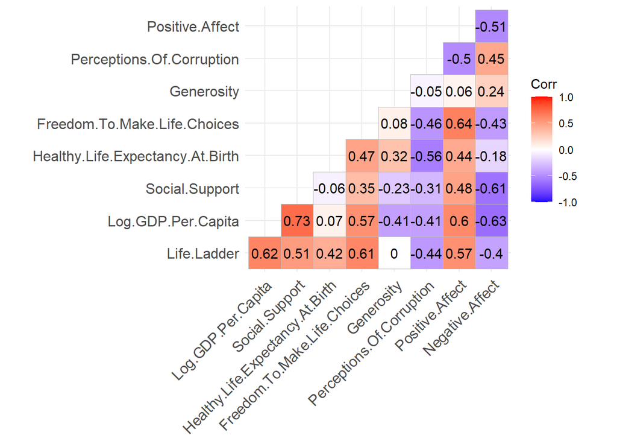

```r
# Your Code Here
balanced2 %>% select(-Country.Name, -Year) %>% cor() %>% ggcorrplot(type = "lower", lab = TRUE)
```

### 1.4.3 Explorasi Socio demografi

Untuk melihat lebih dalam informasi dari data yang kita miliki dapat kita lakukan dengan menggunakan fungsi `coplot()` dengan parameter

- `formula` = diisikan dengan target ~ index1 given index2
- `type` = `"l"` untuk line dan `"b"` untuk point & line plot
- `data` = dataset
- `rows` = banyaknya baris panel plot yang dibuat
- `col` = warna plot yang disajikan

**1. Life.ladder**

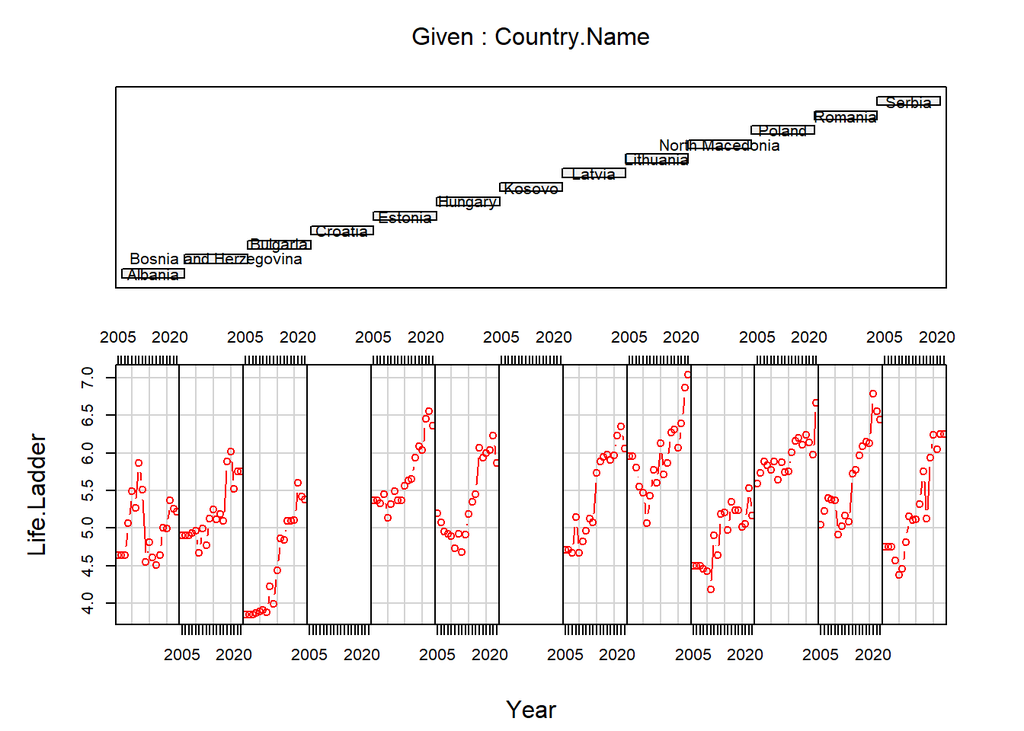

```r
# Your Code Here
coplot(Life.Ladder ~ Year|Country.Name,
       type = "b",
       data = balanced2,
       rows = 1,
       col = "red")
```

Berdasarkan Line plot diatas dapat kita ketahui bahwa :

- secara keseluruhan warga negara yang merasa paling bahagia *di beberapa negara di Central and Eastern Europe* adalah warga negara Lithuania
- secara keseluruhan warga negara yang merasa tingkat kebahagiaan *di beberapa negara di Central and Eastern Europe* paling rendah adalah warga negara Bulgaria

**2. Log.GDP.Per.Capita**

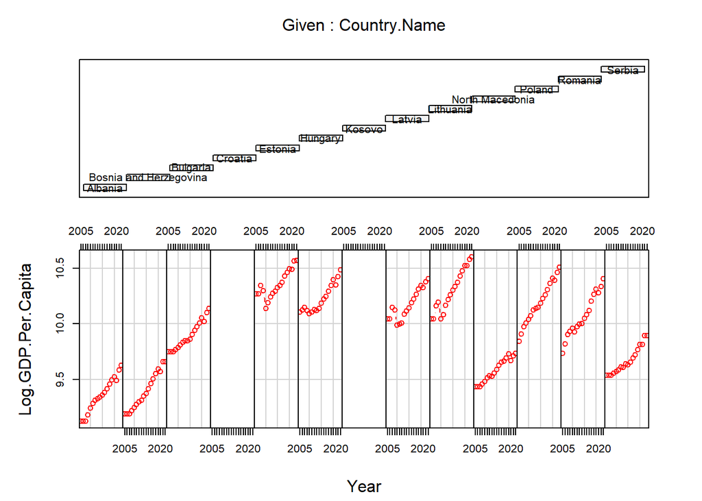

```r
# Your Code Here
coplot(Log.GDP.Per.Capita ~ Year|Country.Name,
       type = "b",
       data = balanced2,
       rows = 1,
       col = "red")
```

Berdasarkan plot diatas dapat kita ketahui bahwa :

- Log Gross Domestic Product per orang di suatu negara yaitu Lithuania

**3. Social.Support**

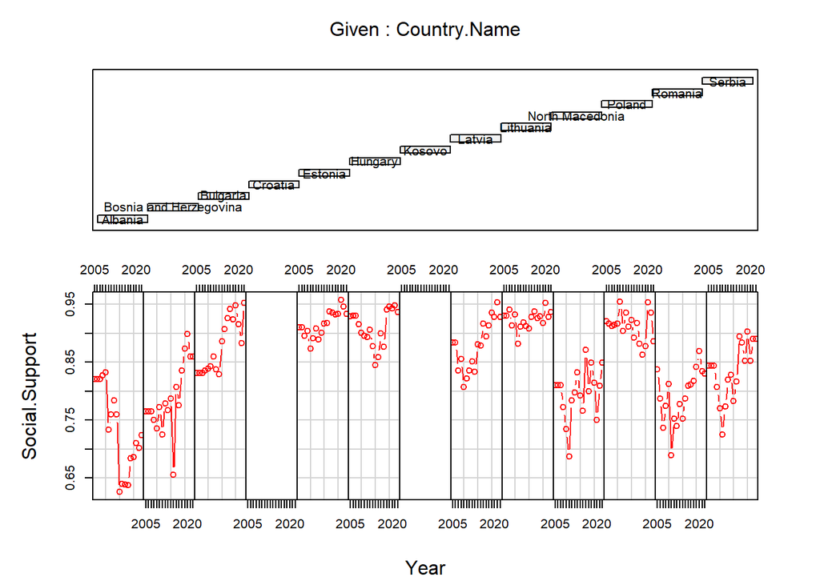

```r
# Your Code Here
coplot(Social.Support ~ Year|Country.Name,
       type = "b",
       data = balanced2,
       rows = 1,
       col = "red")
```

Berdasarkan plot diatas dapat kita ketahui bahwa :

- seseorang yang dapat diandalkan di saat keadaan sulit adalah negara Lithuania

**4. Perceptions.Of.Corruption**

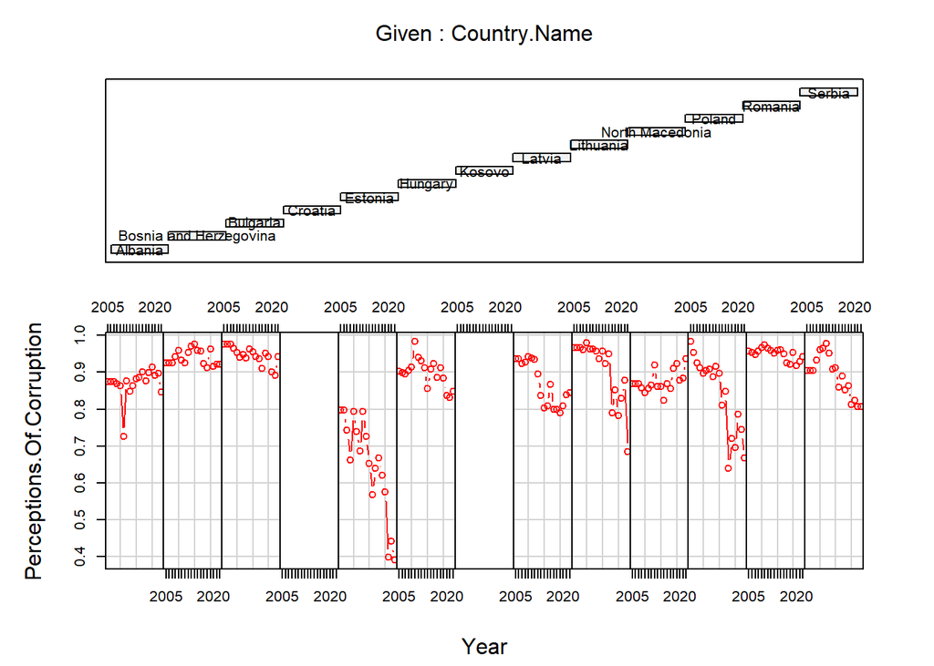

```r
# Perceptions.Of.Corruption
# Your Code Here
coplot(Perceptions.Of.Corruption ~ Year|Country.Name,
       type = "b",
       data = balanced2,
       rows = 1,
       col = "red")
```

Berdasarkan Line plot diatas dapat kita ketahui bahwa :

- Estonia dengan tingkat persepsi korupsi terendah
- Romania dengan tingkat persepsi korupsi tertinggi

### 1.4.4 [Additional] Heterogenitas Life.Ledder

Untuk melihat heterogenitas antar individu dan waktu kita dapat menggunakan fungsi `plotmeans()` dari package gplots dengan parameter:

- formula : Target ~ variabel index individu/waktu
- data : data frame

**1. Heterogenitas antar negara**

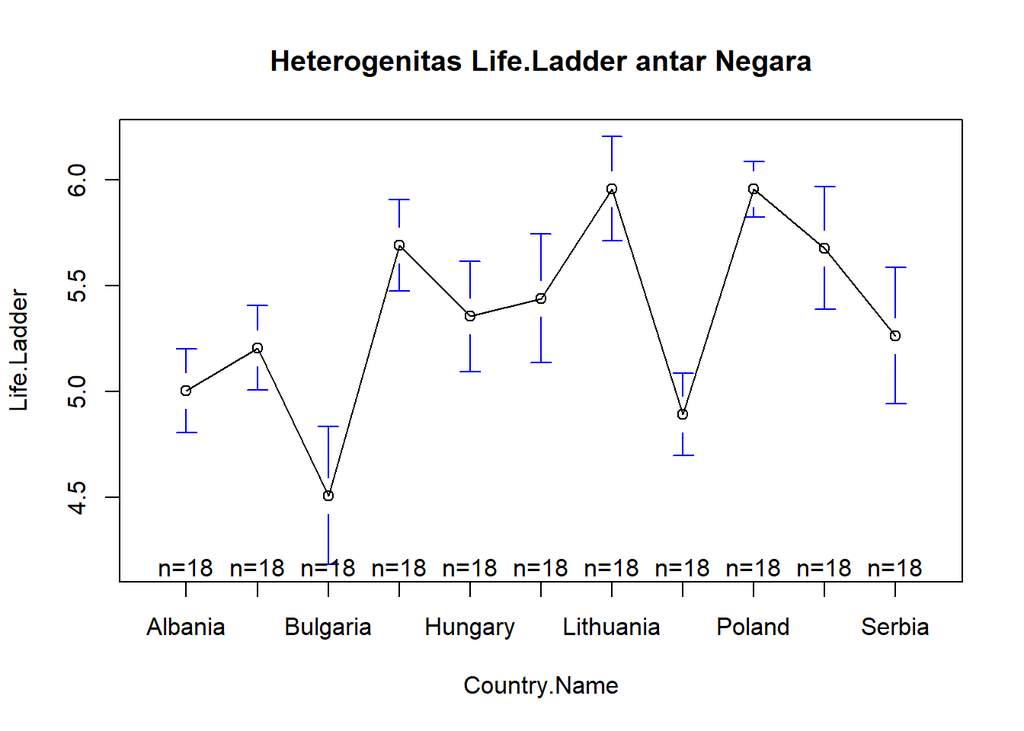

```r
plotmeans( Life.Ladder ~ Country.Name, data = balanced2, main="Heterogenitas Life.Ladder antar Negara")
```

Insight : Berdasarkan hasil visual diatas terlihat bahwa data antar negara cukup heterogen

**2. Heterogenitas antar Waktu**

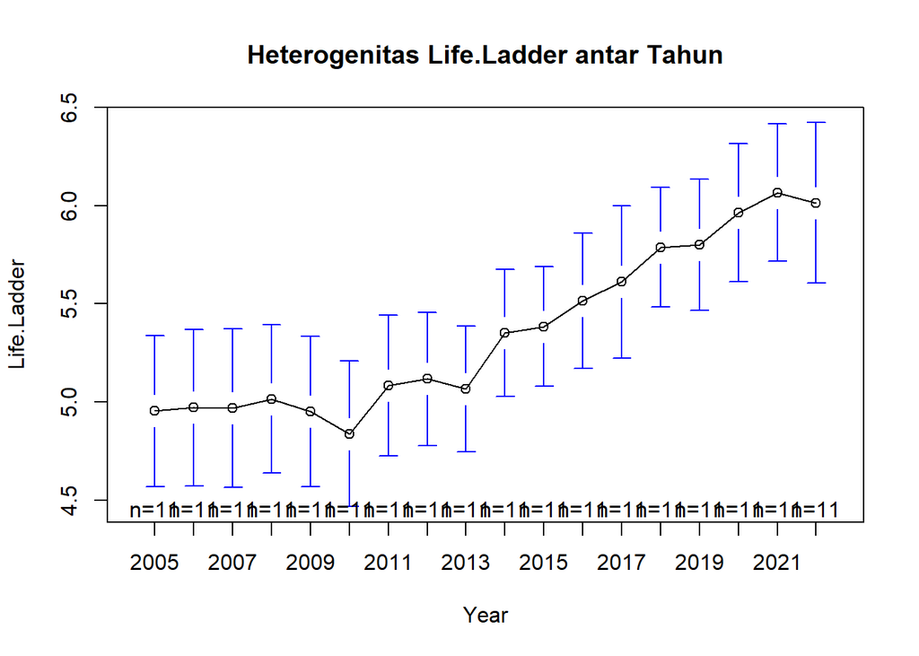

```r
plotmeans(Life.Ladder ~ Year, data = balanced2, main="Heterogenitas Life.Ladder antar Tahun")
```

Insight : Berdasarkan hasil visual diatas terlihat bahwa data antar tahun cukup naik

## 1.5 Pemodelan

### 1.5.1 Cross-Validation

Tahapan cross validation akan selalu dilakukan sebelum pembuatan model, data akan dibagi menjadi data train dan data test. Dikarenakan data panel memiliki informasi keterangan waktu maka pembagian data tidak boleh diambil secara acak melainkan dibagi dengan cara dipisah secara berurutan.

- Data Train akan menggunakan data yang terlampau
- Data Test akan menggunakan data yang terbaru

untuk melakukannya kita bisa menggunakan bantuan fungsi `filter()`

```r
#membuat data train
ladder_train <- balanced2 %>% filter(Year != 2022)

#membuat data test
ladder_test <- balanced2 %>% filter(Year == 2022)
```

setelah dilakukan cross validation kita perlu memastikan kembali bahwa data train sudah balance dengan melakukan balancing

```r
ladder_train <- ladder_train %>%
  droplevels() %>%    # menghapus informasi waktu yang diambil sebagai data test (tahun 2022)
  make.pbalanced()    # melakukan balancing kembali

is.pbalanced(ladder_train)
```

```
#> [1] TRUE
```

### 1.5.2 Pemeriksaan Asumsi Multikolinieritas

Dikarenakan pada hasil pemeriksaan korelasi pada tahapan EDA sebelumnya menunjukkan adanya indikasi multikolinieritas antar variabel prediktor, maka akan dilakukan pemeriksaan asumsi multikolinieritas terlebih dahulu dengan cara pembuatan model regresi dengan fungsi `lm()` dan dilanjutkan pengujian menggunakan fungsi `vif()`.

nilai VIF > 10: terjadi multicollinearity pada model nilai VIF < 10: tidak terjadi multicollinearity pada model

```r
# your code here
lm(Life.Ladder ~ .-Country.Name -Year, ladder_train) %>% vif()
```

```
#>               Log.GDP.Per.Capita                   Social.Support
#>                         4.603151                         2.565625
#> Healthy.Life.Expectancy.At.Birth     Freedom.To.Make.Life.Choices
#>                         2.151463                         2.311700
#>                       Generosity        Perceptions.Of.Corruption
#>                         1.715472                         1.828243
#>                  Positive.Affect                  Negative.Affect
#>                         2.686458                         1.992167
```

### 1.5.3 Penentuan Model Estimasi

#### 1.5.3.1 Pembuatan Model

Untuk setiap pembuatan model akan digunakan fungsi `plm()` dari package plm dengan parameter sebagai berikut:

- `formula` = Target ~ Prediktor
- `data` = berupa dataframe
- `index` = c(“kolom_individu”,“kolom_waktu”)
- `model` =
  - `"pooling"` : untuk model CEM
  - `"within"` : untuk model FEM
  - `"random"` : untuk model REM

dimana

- Variabel target : Life.Ladder
- Variabel prediktor :
  - Log.GDP.Per.Capita
  - Positive.Affect
  - Social.Support
  - Perceptions.Of.Corruption

**Model Gabungan (CEM)**

membuat Common effect model dan disimpan kedalam objek `cem`

```r
# membuat Common effect model
cem <- plm(Life.Ladder ~ Log.GDP.Per.Capita + Social.Support + Perceptions.Of.Corruption + Positive.Affect,
           data = ladder_train,
           index = c("Country.Name","Year"),
           model = "pooling")
```

**Model Pengaruh Tetap (FEM)**

```r
# membuat fixed effect model
fem <- plm(Life.Ladder ~ Log.GDP.Per.Capita + Social.Support + Perceptions.Of.Corruption + Positive.Affect,
           data = ladder_train,
           index = c("Country.Name","Year"),
           model = "within")
```

**Uji Chow**

Uji chow dilakukan untuk memilih model terbaik antara model gabungan (cem) dengan model fixed effec (fem). untuk melakukan uji Chow dapat menggunakan fungsi `pooltest(model_cem, model_fem)`

Hipotesis yang diuji adalah sebagai berikut:

- H0 : Model gabungan
- H1 : Model pengaruh tetap

H0 ditolak jika P-value < α. Nilai α yang digunakan sebesar 5%.

```r
# your code here
pooltest(cem,fem)
```

```
#>
#>  F statistic
#>
#> data:  Life.Ladder ~ Log.GDP.Per.Capita + Social.Support + Perceptions.Of.Corruption +  ...
#> F = 48.981, df1 = 10, df2 = 172, p-value < 0.00000000000000022
#> alternative hypothesis: unstability
```

Berdasarkan hasil uji chow diatas, kita peroleh nilai p-value < α. artinya Model terbaik untuk digunakan pada data World Happines adalah fixed effect model.

**Model Pengaruh Acak (REM)**

membuat random effect model dan disimpan kedalam objek `rem`

```r
# membuat random effect model
rem <- plm(Life.Ladder ~ Log.GDP.Per.Capita + Social.Support + Perceptions.Of.Corruption + Positive.Affect,
           data = ladder_train,
           index = c("Country.Name","Year"),
           model = "random")
```

**Uji Hausman**

- H0 : Model pengaruh acak
- H1 : Model pengaruh tetap

Keputusan tolak H0 (model pengaruh tetap terpilih) apabila nilai p-value < α.

```r
# your code here
phtest(rem,fem)
```

```
#>
#>  Hausman Test
#>
#> data:  Life.Ladder ~ Log.GDP.Per.Capita + Social.Support + Perceptions.Of.Corruption +  ...
#> chisq = 46.756, df = 4, p-value = 0.000000001714
#> alternative hypothesis: one model is inconsistent
```

Berdasarkan hasil uji hausman diatas, kita peroleh nilai p-value < α. artinya Model terbaik untuk digunakan pada data World Happines adalah *fixed effect model*. Dikarenakan model fem adalah model terbaik maka tidak perlu dilakukan uji efek lanjutan, dan bisa langsung dilakukan pengujian asumsi.

#### 1.5.3.2 Pengujian Asumsi

**Normalitas**

Hipotesis yang diuji adalah sebagai berikut.

- H0 : Sisaan menyebar normal
- H1 : Sisaan tidak menyebar normal

H0 ditolak jika P-value < α. Nilai α yang digunakan sebesar 5%.

```r
# your code here
fem$residuals %>% shapiro.test()
```

```
#>
#>  Shapiro-Wilk normality test
#>
#> data:  .
#> W = 0.99625, p-value = 0.9289
```

Berdasarkan hasil pengujian normalitas sisaan diperoleh nilai p-value > 0.05, artinya sisaan menyebar secara normal.

**Homogenitas**

Hipotesis yang diuji adalah sebagai berikut.

- H0 : Sisaan memiliki ragam homogen
- H1 : Sisaan tidak memiliki ragam homogen

H0 ditolak jika P-value < α. Nilai α yang digunakan sebesar 5%.

```r
# your code here
fem %>% bptest()
```

```
#>
#>  studentized Breusch-Pagan test
#>
#> data:  .
#> BP = 14.942, df = 4, p-value = 0.004823
```

**Autokorelasi**

Hipotesis yang diuji adalah sebagai berikut.

- H0 : tidak terjadi autokorelasi pada sisaan
- H1 : terjadi autokorelasi pada sisaan

H0 ditolak jika P-value < α. Nilai α yang digunakan sebesar 5%.

```r
# your code here
fem$residuals %>% Box.test(type = "Ljung-Box")
```

```
#>
#>  Box-Ljung test
#>
#> data:  .
#> X-squared = 34.072, df = 1, p-value = 0.000000005312
```

Berdasarkan hasil pengujian autokorelasi diperoleh nilai p-value < 0.05, artinya terjadi permasalahan autokorelasi antar sisaan.

### 1.5.4 Interpretasi Model

**1. Koefisien**

```r
# your code here
summary(fem)
```

```
#> Oneway (individual) effect Within Model
#>
#> Call:
#> plm(formula = Life.Ladder ~ Log.GDP.Per.Capita + Social.Support +
#>     Perceptions.Of.Corruption + Positive.Affect, data = ladder_train,
#>     model = "within", index = c("Country.Name", "Year"))
#>
#> Balanced Panel: n = 11, T = 17, N = 187
#>
#> Residuals:
#>        Min.     1st Qu.      Median     3rd Qu.        Max.
#> -0.71915116 -0.15408733  0.00045801  0.16908799  0.80216382
#>
#> Coefficients:
#>                           Estimate Std. Error t-value              Pr(>|t|)
#> Log.GDP.Per.Capita         1.77038    0.17249 10.2638 < 0.00000000000000022 ***
#> Social.Support             3.81032    0.45711  8.3356   0.00000000000002373 ***
#> Perceptions.Of.Corruption -0.89491    0.37948 -2.3582             0.0194855 *
#> Positive.Affect            1.88803    0.49919  3.7822             0.0002143 ***
#> ---
#> Signif. codes:  0 '***' 0.001 '**' 0.01 '*' 0.05 '.' 0.1 ' ' 1
#>
#> Total Sum of Squares:    42.154
#> Residual Sum of Squares: 10.661
#> R-Squared:      0.74709
#> Adj. R-Squared: 0.7265
#> F-statistic: 127.018 on 4 and 172 DF, p-value: < 0.000000000000000222
```

**2. Mengekstrak informasi Efek dari model fix**

Untuk mengekstrak informasi efek dari model FEM kita dapat menggunakan fungsi `fixef(model fem)`,

```r
# your code here
fixef(fem)
```

```
#>                Albania Bosnia and Herzegovina               Bulgaria
#>                -14.595                -14.582                -16.545
#>                Estonia                Hungary                 Latvia
#>                -16.785                -16.552                -16.259
#>              Lithuania        North Macedonia                 Poland
#>                -16.047                -15.315                -16.042
#>                Romania                 Serbia
#>                -15.428                -15.197
```

Interpretasi:

- tingkat kebahagiaan masyarakat di negara Albania adalah sebesar -14.595 apabila tidak terdapat informasi lainnya
- tingkat kebahagiaan masyarakat di negara Hungary adalah sebesar -16.552 apabila tidak terdapat informasi lainnya
- tingkat kebahagiaan masyarakat di negara Poland adalah sebesar -16.042 apabila tidak terdapat informasi lainnya
- tingkat kebahagiaan masyarakat di negara Bosnia and Herzegovina adalah sebesar -14.582 apabila tidak terdapat informasi lainnya
- tingkat kebahagiaan masyarakat di negara Latvia adalah sebesar -16.259 apabila tidak terdapat informasi lainnya
- tingkat kebahagiaan masyarakat di negara Romania adalah sebesar -15.428 apabila tidak terdapat informasi lainnya
- tingkat kebahagiaan masyarakat di negara Bulgaria adalah sebesar -16.545 apabila tidak terdapat informasi lainnya
- tingkat kebahagiaan masyarakat di negara Lithuania and Herzegovina adalah sebesar -16.047 apabila tidak terdapat informasi lainnya
- tingkat kebahagiaan masyarakat di negara Serbia adalah sebesar -15.197 apabila tidak terdapat informasi lainnya
- tingkat kebahagiaan masyarakat di negara Estonia adalah sebesar -16.785 apabila tidak terdapat informasi lainnya
- tingkat kebahagiaan masyarakat di negara North Macedonia adalah sebesar -15.315 apabila tidak terdapat informasi lainnya

### 1.5.5 Prediksi & Evaluasi

Untuk melakukan prediksi akan kita gunakan fungsi `predict()` dengan parameter:

- object = nama model yang kita gunakan
- newdata = data baru yang akan kita prediksi

```r
# your code here
pred <- predict(fem, ladder_test, na.fill = F)
```

Untuk menguji apakah model yang kita miliki sudah baik dalam memprediksi data baru maka kita akan evaluasi dengan menggunakan nilai error, salah satu metric eror yang biasa digunakan adalah MAPE. Kita dapat melakukannya menggunakan fungsi `MAPE()` dengan parameter:

- y_pred = nilai hasil prediksi
- y_true = nilai target asli

```r
# your code here
MAPE(y_pred = pred,
     y_true = ladder_test$Life.Ladder)
```

```
#> [1] NA
```

# 2 Kesimpulan